# Project #1

Ziad Al Bkhetan, Karolina Kwasiborska, Tomasz Zaremba

October 22, 2015

# Introduction

in this project we will use two different classifiers * k nearest neighbours * random forest

# DataSet preprocessing

Starting with data loading into the variable australianDataSet using R script Data Link is http://archive.ics.uci.edu/ml/machine-learning-databases/statlog/australian/australian.dat

```r
australianDataSet = read.table("C:\\Users\\Tomek\\Desktop\\Studia\\MSc\\Semestr 2\\Data mining\\Projekty\\1\\australian.dat",
        sep=" ",header=F,col.names=c("A1", "A2", "A3", "A4",
                "A5","A6", "A7", "A8", "A9","A10",
                "A11", "A12", "A13","A14", "A15"),
        fill=FALSE,strip.white=T)
head(australianDataSet)
```

```
##   A1    A2     A3 A4 A5 A6    A7 A8 A9 A10 A11 A12 A13  A14 A15
## 1  1 22.08 11.460  2  4  4 1.585  0  0   0   1   2 100 1213   0
## 2  0 22.67  7.000  2  8  4 0.165  0  0   0   0   2 160    1   0
## 3  0 29.58  1.750  1  4  4 1.250  0  0   0   1   2 280    1   0
## 4  0 21.67 11.500  1  5  3 0.000  1  1  11   1   2   0    1   1
## 5  1 20.17  8.170  2  6  4 1.960  1  1  14   0   2  60  159   1
## 6  0 15.83  0.585  2  8  8 1.500  1  1   2   0   2 100    1   1
```

Create factor Variable for the target attribute A15

```r
australianDataSet$A15 = factor(australianDataSet$A15)
```

Data Normalization

```r
australianDataSet$A14 <- (australianDataSet$A14 - min(australianDataSet$A14))/(max(australianDataSet$A14) + min(australianDataSet$A14))

australianDataSet$A10 <- (australianDataSet$A10 - min(australianDataSet$A10))/(max(australianDataSet$A10) + min(australianDataSet$A10))

australianDataSet$A5 <- (australianDataSet$A5 - min(australianDataSet$A5))/(max(australianDataSet$A5) + min(australianDataSet$A5))

australianDataSet$A7 <- (australianDataSet$A7 - min(australianDataSet$A7))/(max(australianDataSet$A7) + min(australianDataSet$A7))

australianDataSet$A13 <- (australianDataSet$A13 - min(australianDataSet$A13))/(max(australianDataSet$A13) + min(australianDataSet$A13))
```

Summary

```r
summary(australianDataSet)
```

```
##        A1               A2              A3               A4
##  Min.   :0.0000   Min.   :13.75   Min.   : 0.000   Min.   :1.000
##  1st Qu.:0.0000   1st Qu.:22.67   1st Qu.: 1.000   1st Qu.:2.000
##  Median :1.0000   Median :28.62   Median : 2.750   Median :2.000
##  Mean   :0.6783   Mean   :31.57   Mean   : 4.759   Mean   :1.767
##  3rd Qu.:1.0000   3rd Qu.:37.71   3rd Qu.: 7.207   3rd Qu.:2.000
##  Max.   :1.0000   Max.   :80.25   Max.   :28.000   Max.   :3.000
##        A5               A6              A7                A8
##  Min.   :0.0000   Min.   :1.000   Min.   :0.00000   Min.   :0.0000
##  1st Qu.:0.2000   1st Qu.:4.000   1st Qu.:0.00579   1st Qu.:0.0000
##  Median :0.4667   Median :4.000   Median :0.03509   Median :1.0000
##  Mean   :0.4248   Mean   :4.693   Mean   :0.07801   Mean   :0.5232
##  3rd Qu.:0.6000   3rd Qu.:5.000   3rd Qu.:0.09211   3rd Qu.:1.0000
##  Max.   :0.8667   Max.   :9.000   Max.   :1.00000   Max.   :1.0000
##        A9              A10               A11             A12
##  Min.   :0.0000   Min.   :0.00000   Min.   :0.000   Min.   :1.000
##  1st Qu.:0.0000   1st Qu.:0.00000   1st Qu.:0.000   1st Qu.:2.000
##  Median :0.0000   Median :0.00000   Median :0.000   Median :2.000
##  Mean   :0.4275   Mean   :0.03582   Mean   :0.458   Mean   :1.929
##  3rd Qu.:1.0000   3rd Qu.:0.04478   3rd Qu.:1.000   3rd Qu.:2.000
##  Max.   :1.0000   Max.   :1.00000   Max.   :1.000   Max.   :3.000
##       A13               A14           A15
##  Min.   :0.00000   Min.   :0.000000   0:383
##  1st Qu.:0.04000   1st Qu.:0.000000   1:307
##  Median :0.08000   Median :0.000050
##  Mean   :0.09201   Mean   :0.010174
##  3rd Qu.:0.13600   3rd Qu.:0.003955
##  Max.   :1.00000   Max.   :0.999980
```

# Data Partitioning

in this phase we will divide the dataset into two different sets the first one for classifier training while the second is for the classifier testing.  
* partion percentage is 75:25  
* target attribute to maintain good distribution “A15”

```r
library(lattice)
library(ggplot2)
library(caret)
indxTrainSet <- createDataPartition(y = australianDataSet$A15, p=0.75)
str(indxTrainSet)
```

```
## List of 1
##  $ Resample1: int [1:519] 1 2 3 4 5 6 7 8 9 10 ...
```

```r
australianDataSetTrain <- australianDataSet[indxTrainSet$Resample1,]
#australianDataSetTrain
australianDataSetTest <- australianDataSet[-indxTrainSet$Resample1,]
#australianDataSetTest
```

# Data Distribution Visualization

This visualization is based on A2 and A3 dimensions

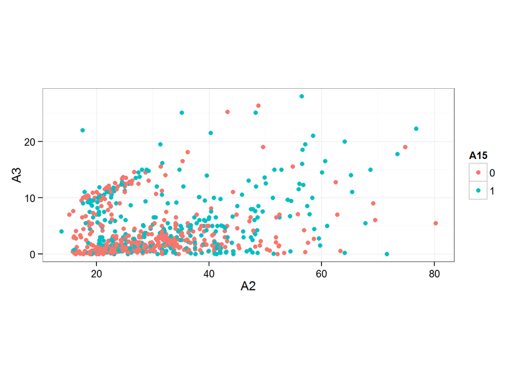

```r
levels(australianDataSet$A15) <- c("0", "1")

ggplot(australianDataSet, aes(A2, A3, color=A15)) +
  geom_point() +
  theme_bw() + coord_fixed()
```

# Finding Best K for Classification

used model is A8 + A14 + A10 + A5 +A7 + A13 + A9

```
## geom_smooth: method="auto" and size of largest group is <1000, so using loess. Use 'method = x' to change the smoothing method.
```

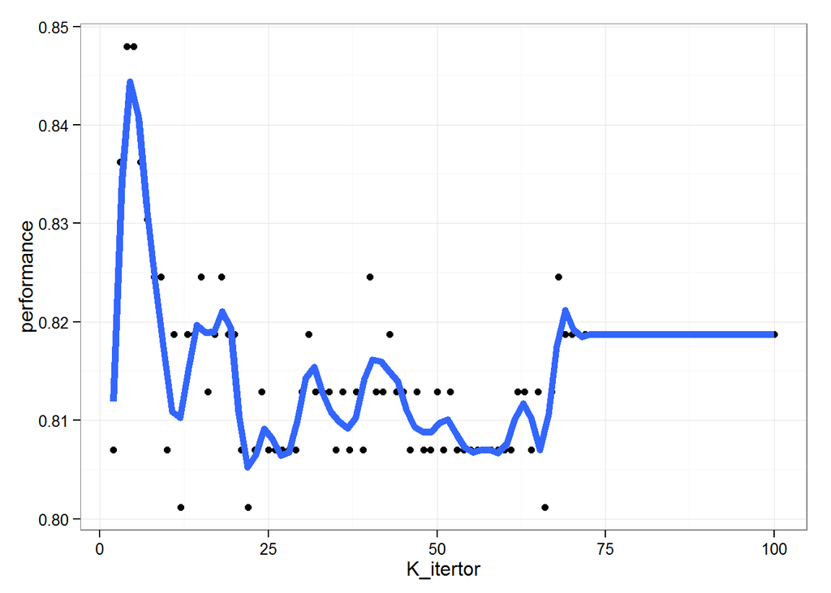

```r
library(caret)
K_itertor <- 2:100
performance <- sapply(K_itertor, function(k) {
  KnnClassifier_k <- knn3(A15 ~ A8 + A14 + A10 + A5 +A7 + A13 + A9, data = australianDataSetTrain, k=k)
  tab <- table(true = australianDataSetTest$A15,
          predict = predict(KnnClassifier_k, australianDataSetTest, type="class"))
  sum(diag(tab)) / sum(tab)

})



df <- data.frame(K_itertor, performance)

ggplot(df, aes(K_itertor, performance)) +
  geom_point() +
  geom_smooth(se=FALSE, span=0.1, size=2) +
  theme_bw()
```

```r
best_k = which.max(performance)
best_k
```

```
## [1] 3
```

```r
# Accuracy for best k:
performance[best_k]
```

```
## [1] 0.8479532
```

# K Nearest Neighbours Classifier - Training Phase

```r
knnClassifier <- knn3(A15 ~ A8 + A14 + A10 + A5 +A7 + A13 + A9, data = australianDataSetTrain, k=best_k)
knnClassifier
```

```
## 3-nearest neighbor classification model
## Training set class distribution:
##
##   0   1
## 288 231
```

# K Nearest Neighbours Classifier - Testing Phase

in this step we will apply our classifier on the test data test to check its efficiency:

```r
predAust <- predict(knnClassifier, australianDataSetTest, type="class")

tab <- table(true = australianDataSetTest$A15, predicted = predAust)
tab
```

```
##     predicted
## true  0  1
##    0 79 16
##    1 12 64
```

# K Nearest Neighbours results:

```r
mesTab <- matrix(c("TP", "FN", "FP", "TN"), ncol=2, nrow = 2, byrow = TRUE)
colnames(mesTab) <- c("0", "1")
rownames(mesTab) <- c("0", "1")
mesTab
```

```
##   0    1
## 0 "TP" "FN"
## 1 "FP" "TN"
```

Accuracy : the percentage of the correct prediction . (TP + TN) / (TP + TN + FP + FN)

```r
sum(diag(tab)) / sum(tab)
```

```
## [1] 0.8362573
```

Precision : The percentage of positive predictions that are correct (Positive = 0, negative = 1). TP / (TP + FP)

```r
tab[[1]] / (tab[[1]] + tab[[2]])
```

```
## [1] 0.8681319
```

Sensitivity : The percentage of positive labeled instances that were predicted as positive. TP / (TP + FN)

```r
tab[[1]] / (tab[[1]] + tab[[3]])
```

```
## [1] 0.8315789
```

Specificity : The percentage of negative labeled instances that were predicted as negative. TN / (TN + FP)

```r
tab[[4]] / (tab[[4]] + tab[[2]])
```

```
## [1] 0.8421053
```

# Random forest for all variables

```r
library(randomForest)
allVariablesForest <- randomForest(A15 ~ ., data = australianDataSetTrain, importance = TRUE, na.action = na.omit)
```

Importance of variables:

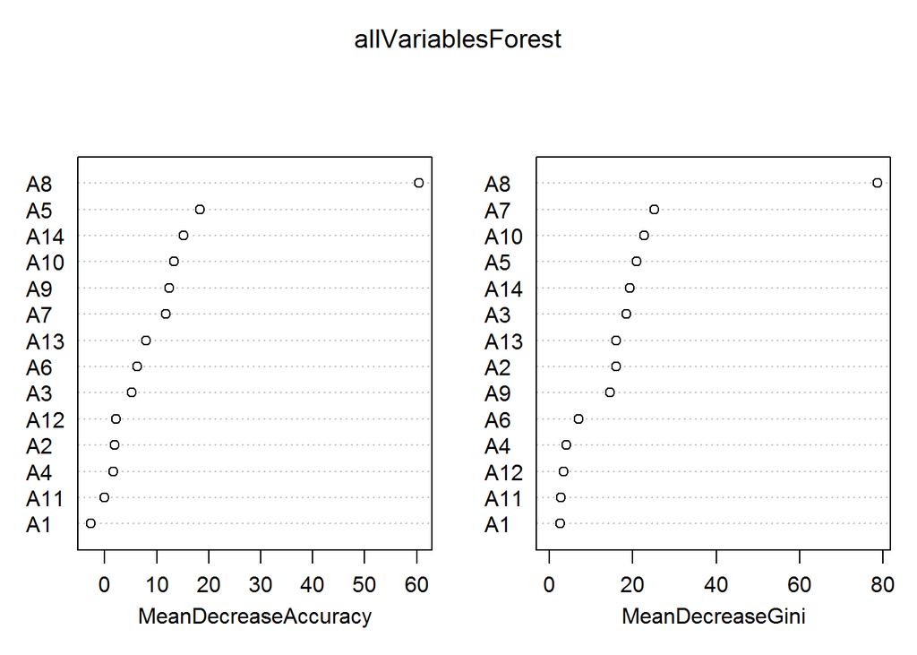

```r
varImpPlot(allVariablesForest)
```

```r
importance(allVariablesForest)
```

```
##              0          1 MeanDecreaseAccuracy MeanDecreaseGini
## A1  -2.1307143 -1.6217634         -2.632115026         2.622857
## A2   1.9882876  0.7828565          1.944073555        16.003775
## A3  -0.3332508  7.5264527          5.179945109        18.436238
## A4   0.9410519  1.5759329          1.679519805         3.978268
## A5  15.3474348 11.7878369         18.345675706        20.919164
## A6   5.1773632  3.8601351          6.223160657         6.948680
## A7   5.6613103 10.1556748         11.786202827        25.218654
## A8  51.2495601 49.5393612         60.425681410        78.682801
## A9   7.1483551 10.2676493         12.360890977        14.512350
## A10  9.6248103 10.3037383         13.366165921        22.654855
## A11 -0.4290843  0.4585216          0.001332676         2.805634
## A12 -3.3906873  6.2521657          2.219808978         3.347438
## A13  5.3725852  5.9176946          7.991088573        16.016519
## A14 12.2313514  9.0909356         15.210398968        19.285417
```

Prediction using the forest:

```r
allVariablesPrediction = predict(allVariablesForest, australianDataSetTest, type="class")
allVariablesTab <- table(true = australianDataSetTest$A15, predicted = allVariablesPrediction)
```

Prediction accuracy:

```r
sum(diag(allVariablesTab)) / sum(allVariablesTab)
```

```
## [1] 0.8304094
```

# Random forest for the same variables as in k nearest neighbours

```r
kNearestNeighboursForest <- randomForest(A15 ~ A8 + A14 + A10 + A5 +A7 + A13 + A9, data = australianDataSetTrain, importance = TRUE, na.action = na.omit)
```

Importance of variables:

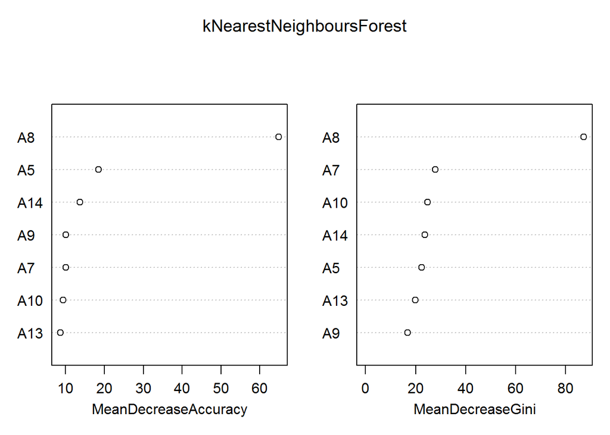

```r
varImpPlot(kNearestNeighboursForest)
```

```r
importance(kNearestNeighboursForest)
```

```
##             0         1 MeanDecreaseAccuracy MeanDecreaseGini
## A8  49.891862 56.490786            64.848969         87.15080
## A14 12.463959  6.338443            13.747014         23.65195
## A10  6.193436  7.032452             9.337524         24.80680
## A5  16.038514  9.912613            18.473886         22.39189
## A7   4.542577  9.154051            10.046127         27.84792
## A13  6.569951  6.178888             8.711359         19.89627
## A9   7.013264  8.299130            10.100644         16.73625
```

Prediction using the forest:

```r
kNearestNeighboursForestPrediction = predict(kNearestNeighboursForest, australianDataSetTest, type="class")
kNearestNeighboursPredictionTab <- table(true = australianDataSetTest$A15, predicted = kNearestNeighboursForestPrediction)
```

Prediction accuracy:

```r
sum(diag(kNearestNeighboursPredictionTab)) / sum(kNearestNeighboursPredictionTab)
```

```
## [1] 0.8479532
```

Precision:

```r
kNearestNeighboursPredictionTab[[1]] / (kNearestNeighboursPredictionTab[[1]] + kNearestNeighboursPredictionTab[[2]])
```

```
## [1] 0.8965517
```

Sensitivity:

```r
kNearestNeighboursPredictionTab[[1]] / (kNearestNeighboursPredictionTab[[1]] + kNearestNeighboursPredictionTab[[3]])
```

```
## [1] 0.8210526
```

Specificity:

```r
kNearestNeighboursPredictionTab[[4]] / (kNearestNeighboursPredictionTab[[4]] + kNearestNeighboursPredictionTab[[2]])
```

```
## [1] 0.8815789
```